# Assignment 7: Linear Model Selection and Regularization

Dataset(s) needed: Kaggle House Prices (https://www.kaggle.com/c/house-prices-advanced-regression-techniques/data)

## Learning Objectives

- Produce a model with l2 regularization, with a statistically significant improvement over a model without regularization.
- Produce a model with l1 regularization, with a statistically significant improvement over a model without regularization.
- Produce a model with both l1 and l2 regularization terms, with a statistically significant improvement over a model without regularization.
- Produce a logistic regression model with a statistically significant improvement over the null model (a model without input - variables).
- Produce a generalized additive model with a statistically significant improvement over the null model (a model without input variables).

```python
import pandas as pd
import numpy as np
import seaborn as sns

houses = pd.read_csv('House Prices.csv')
houses.head()
```

|  | Id | MSSubClass | MSZoning | LotFrontage | LotArea | Street | Alley | LotShape | LandContour | Utilities | ... | PoolArea | PoolQC | Fence | MiscFeature | MiscVal | MoSold | YrSold | SaleType | SaleCondition | SalePrice |
| --- | --- | --- | --- | --- | --- | --- | --- | --- | --- | --- | --- | --- | --- | --- | --- | --- | --- | --- | --- | --- | --- |
| 0 | 1 | 60 | RL | 65.0 | 8450 | Pave | NaN | Reg | Lvl | AllPub | ... | 0 | NaN | NaN | NaN | 0 | 2 | 2008 | WD | Normal | 208500 |
| 1 | 2 | 20 | RL | 80.0 | 9600 | Pave | NaN | Reg | Lvl | AllPub | ... | 0 | NaN | NaN | NaN | 0 | 5 | 2007 | WD | Normal | 181500 |
| 2 | 3 | 60 | RL | 68.0 | 11250 | Pave | NaN | IR1 | Lvl | AllPub | ... | 0 | NaN | NaN | NaN | 0 | 9 | 2008 | WD | Normal | 223500 |
| 3 | 4 | 70 | RL | 60.0 | 9550 | Pave | NaN | IR1 | Lvl | AllPub | ... | 0 | NaN | NaN | NaN | 0 | 2 | 2006 | WD | Abnorml | 140000 |
| 4 | 5 | 60 | RL | 84.0 | 14260 | Pave | NaN | IR1 | Lvl | AllPub | ... | 0 | NaN | NaN | NaN | 0 | 12 | 2008 | WD | Normal | 250000 |

5 rows × 81 columns

Question 1.1: Drop the Id column as it is not needed for prediction

```python
houses.drop(['Id'], axis=1, inplace=True)
houses.shape
```

```
(1460, 80)
```

Question 1.2: Visualize a scatter plot of 'GrLivArea' in the x-axis and 'SalePrice' in the y-axis. Can you spot any outliers?

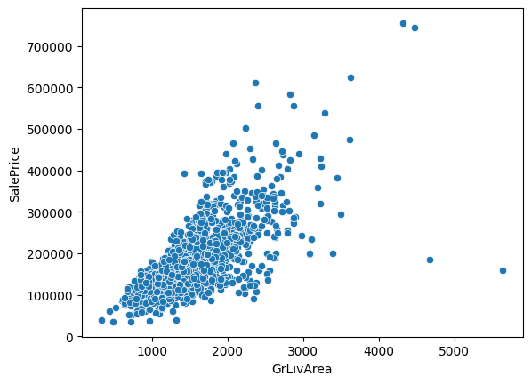

```python
import seaborn as sns
sns.scatterplot(data=houses, x='GrLivArea', y='SalePrice')
```

```
163000.0
```

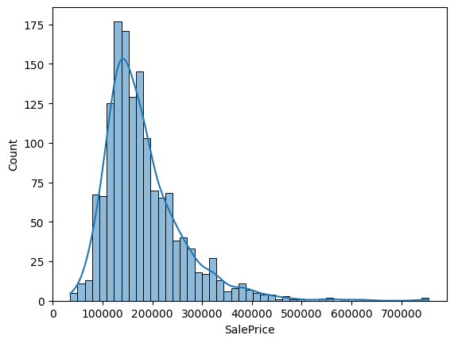

```python
# Want to see how the distribution looks like before proceeding with the analysis
sns.histplot(houses['SalePrice'], kde=True)

median_sale_price = houses['SalePrice'].median()
print(median_sale_price)
# This has got to be old data! Medial sales price of 163,000 is low!!!
```

Question 1.3: Removing outliers in the data for all GrLivArea greater than 4000 then check the scatter plot again

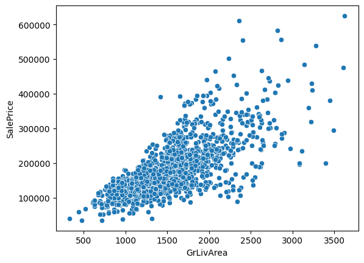

```python
# Remove outliers for data['GrLivArea']>4000
houses = houses[houses['GrLivArea'] <= 4000]

#To Do Create a scatter plot
sns.scatterplot(data=houses, x='GrLivArea', y='SalePrice')
```

Quesiont 2.1: Convert categorical variable into dummy variables using pandas get_dummies API

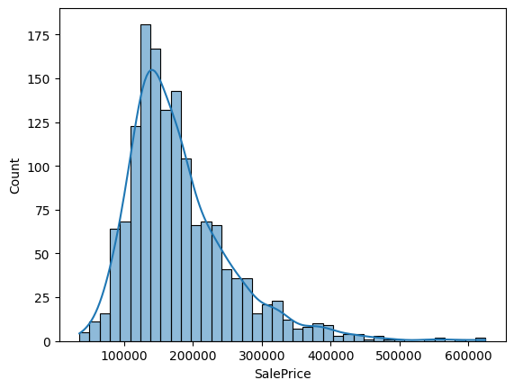

```python
# This gets all non-numeric columns
housing_categorical = houses.select_dtypes(include=['object'])

# Now we can use the get_dummies function to convert the categorical variables into dummy variables
housing_dummies = pd.get_dummies(housing_categorical, drop_first=True, dtype=int)


#drop the categorical columns from the original dataframe
temp_df = houses.drop(list(housing_categorical.columns), axis=1)

# NOTE I removed all scaling since it was making results much worse later
# also I was scaling both X and Y which is not standard procedure.
# scale all the numeric columns using a standard scaler
# from sklearn.preprocessing import StandardScaler
# scaler = StandardScaler()
# scaler.fit(temp_df)
# temp_df = pd.DataFrame(scaler.transform(temp_df), columns=temp_df.columns)

# concatenate the scaled numeric columns with the dummy variables
houses = pd.concat([temp_df, housing_dummies], axis=1)

# Lets look at the data again now that we've scaled it
sns.histplot(houses['SalePrice'], kde=True)
```

```python
housing_dummies
# wanted to verify that I have numeric values instead of True/False
```

|  | MSZoning_FV | MSZoning_RH | MSZoning_RL | MSZoning_RM | Street_Pave | Alley_Pave | LotShape_IR2 | LotShape_IR3 | LotShape_Reg | LandContour_HLS | ... | SaleType_ConLI | SaleType_ConLw | SaleType_New | SaleType_Oth | SaleType_WD | SaleCondition_AdjLand | SaleCondition_Alloca | SaleCondition_Family | SaleCondition_Normal | SaleCondition_Partial |
| --- | --- | --- | --- | --- | --- | --- | --- | --- | --- | --- | --- | --- | --- | --- | --- | --- | --- | --- | --- | --- | --- |
| 0 | 0 | 0 | 1 | 0 | 1 | 0 | 0 | 0 | 1 | 0 | ... | 0 | 0 | 0 | 0 | 1 | 0 | 0 | 0 | 1 | 0 |
| 1 | 0 | 0 | 1 | 0 | 1 | 0 | 0 | 0 | 1 | 0 | ... | 0 | 0 | 0 | 0 | 1 | 0 | 0 | 0 | 1 | 0 |
| 2 | 0 | 0 | 1 | 0 | 1 | 0 | 0 | 0 | 0 | 0 | ... | 0 | 0 | 0 | 0 | 1 | 0 | 0 | 0 | 1 | 0 |
| 3 | 0 | 0 | 1 | 0 | 1 | 0 | 0 | 0 | 0 | 0 | ... | 0 | 0 | 0 | 0 | 1 | 0 | 0 | 0 | 0 | 0 |
| 4 | 0 | 0 | 1 | 0 | 1 | 0 | 0 | 0 | 0 | 0 | ... | 0 | 0 | 0 | 0 | 1 | 0 | 0 | 0 | 1 | 0 |
| ... | ... | ... | ... | ... | ... | ... | ... | ... | ... | ... | ... | ... | ... | ... | ... | ... | ... | ... | ... | ... | ... |
| 1455 | 0 | 0 | 1 | 0 | 1 | 0 | 0 | 0 | 1 | 0 | ... | 0 | 0 | 0 | 0 | 1 | 0 | 0 | 0 | 1 | 0 |
| 1456 | 0 | 0 | 1 | 0 | 1 | 0 | 0 | 0 | 1 | 0 | ... | 0 | 0 | 0 | 0 | 1 | 0 | 0 | 0 | 1 | 0 |
| 1457 | 0 | 0 | 1 | 0 | 1 | 0 | 0 | 0 | 1 | 0 | ... | 0 | 0 | 0 | 0 | 1 | 0 | 0 | 0 | 1 | 0 |
| 1458 | 0 | 0 | 1 | 0 | 1 | 0 | 0 | 0 | 1 | 0 | ... | 0 | 0 | 0 | 0 | 1 | 0 | 0 | 0 | 1 | 0 |
| 1459 | 0 | 0 | 1 | 0 | 1 | 0 | 0 | 0 | 1 | 0 | ... | 0 | 0 | 0 | 0 | 1 | 0 | 0 | 0 | 1 | 0 |

1456 rows × 207 columns

Question 2.2: Impute missing data by the median of each column.

```python
# Fill in missing values with the median of the column
houses = houses.fillna(houses.median())
```

Question 2.2b: Make sure that there are no null values remaining

```python
print(houses.isnull().sum())
print("Total columns with null ", houses.isnull().sum().sum())
```

```
MSSubClass               0
LotFrontage              0
LotArea                  0
OverallQual              0
OverallCond              0
                        ..
SaleCondition_AdjLand    0
SaleCondition_Alloca     0
SaleCondition_Family     0
SaleCondition_Normal     0
SaleCondition_Partial    0
Length: 244, dtype: int64
Total columns with null  0
```

Question 2.3: Generate train test split 70/30. Set random_state=42

```python
from sklearn.model_selection import train_test_split
Y = houses['SalePrice']
X = houses.drop(['SalePrice'], axis=1)

X_train, X_test, y_train, y_test = train_test_split(X, Y, test_size=0.3, random_state=42)

print(X_train.shape, X_test.shape, y_train.shape, y_test.shape)
```

```
(1019, 243) (437, 243) (1019,) (437,)
```

Question 3.1: Train a linear regression algorithm to predict `SalePrice` from the remaining features.

```python
from sklearn.linear_model import Ridge, RidgeCV, ElasticNet, LassoCV, LassoLarsCV, LinearRegression, ElasticNetCV
from sklearn.metrics import mean_squared_error

#Fit a linear regression model to this data
lr = LinearRegression()
lr.fit(X_train, y_train)
```

```
LinearRegression()
```

Question 3.2: Evaluate the model and report the performance on both training and test data. These numbers will serve as our benchmark performance.

```
23764.9017284519
```

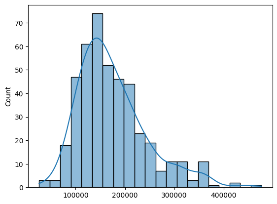

```python
#Compute the RMSE
# Predict the values of Y_test
y_pred = lr.predict(X_test)

sns.histplot(y_pred, kde=True)

# Compute the RMSE accuracy
rmse_lr = np.sqrt(mean_squared_error(y_test, y_pred))
rmse_lr
```

We now train a regularized version of `LinearRegression` called `Lasso` (you can load it from the same library). `Lasso` has an argument called `alpha`, which is the **shrinkage parameter** we referred to earlier.

Question 4.1: Let `alpha = 0.000001` and train a `Lasso` algorithm. Show that the resulting model is practically identical to the one we trained with `LinearRegression`. There are different ways to show this, so you will need to think of a way. [2 point]

```python
from sklearn.linear_model import Lasso

lasso = Lasso(alpha=0.000001, max_iter=5_000)
lasso.fit(X_train, y_train)

# Predict the values of Y_test
y_pred_lasso = lasso.predict(X_test)

#Compute the RMSE
rmse = np.sqrt(mean_squared_error(y_test, y_pred_lasso))
rmse

# YES, this RMSE is barely any different than the linear regression model RMSE
```

```
23789.76806635538
```

Regarding the WHY part of question 4.1 above. If we look at the equation for Lasso...

$$CostLasso=RSS+α∑j=1p∣βj∣$$

As α becomes close to zero, the extra "penalty" sum also approches zero which means we are just left with RSS which is the same as linear regression cost function.

Question 4.2: Iteratively train a new `Lasso` model, letting `alpha` change each time to one of the values given by `alpha_vals` below, keeping track of the performance on the training and test data each time, and storing the model's coefficients each time (the `coef_` attribute of the trained model)

```python
from sklearn.linear_model import Lasso
alpha_vals = np.arange(0.01, 5, .01)

# This is shown in the Case Study
pd.DataFrame({'linreg': lr.coef_, 'lasso': lasso.coef_}).head(10)

# Create a dict to store the results of the RMSE
lasso_results = dict()

for alpha in alpha_vals:
    lasso = Lasso(alpha=alpha, max_iter=5_000)
    lasso.fit(X_train, y_train)
    y_pred_lasso = lasso.predict(X_test)
    rmse = np.sqrt(mean_squared_error(y_test, y_pred_lasso))
    lasso_results[alpha] = (rmse, lasso.coef_)

#print(results)
```

Question 4.3: Using a visual, show how the performance on the training and test data changed as we gradually increased `alpha`.

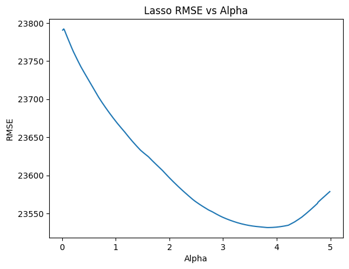

```
3.83
23531.426145184992
```

```python
import seaborn as sns
import matplotlib.pyplot as plt

# Extract the alpha values and rmse values from the dictionary
alphas = list(lasso_results.keys())
#rmse_values = list(results.values()[0])
# Assuming your dictionary is called 'your_dict'
rmse_values = [value[0] for value in lasso_results.values()]
coefficients = [value[1] for value in lasso_results.values()]

# Plot the values
sns.lineplot(x=alphas, y=rmse_values)
plt.xlabel('Alpha')
plt.ylabel('RMSE')
plt.title('Lasso RMSE vs Alpha')
plt.show()

min_alpha = min(lasso_results, key=lambda x: lasso_results[x])
print(min_alpha)
print(lasso_results[min_alpha][0])
```

Question 4.4: Using a visual, show how the model's coefficients changed as we gradually increased the shrinkage parameter `alpha`. HINT: They should appear to be shrinking toward zero as you increase `alpha`!

## Note to grader.

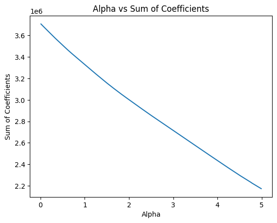

```python
import matplotlib.pyplot as plt

# Get the alpha values and sum of coefficients from the results dictionary
coeff_sum = [sum(abs(coefficients)) for _, coefficients in lasso_results.values()]

# Plot alpha vs sum of coefficients
plt.plot(alphas, coeff_sum)
plt.xlabel('Alpha')
plt.ylabel('Sum of Coefficients')
plt.title('Alpha vs Sum of Coefficients')
plt.show()
```

Question 5.1: Repeat steps in Question 4 this time using `Ridge` instead of `Lasso`. We will use the following range for `alpha`: [2 point]

```python
alpha_vals = np.arange(0.1, 200, 1)

# This is shown in the Case Study
#pd.DataFrame({'linreg': lr.coef_, 'lasso': lasso.coef_}).head(10)

# Create a dict to store the results of the RMSE
ridge_results = dict()

for alpha in alpha_vals:
    ridge = Ridge(alpha=alpha, max_iter=5_000)
    ridge.fit(X_train, y_train)
    y_pred_ridge = ridge.predict(X_test)
    rmse_ridge = np.sqrt(mean_squared_error(y_test, y_pred_ridge))
    ridge_results[alpha] = (rmse_ridge, ridge.coef_)
```

```python
pd.DataFrame({'linreg': lr.coef_, 'ridge': ridge.coef_}).head(10)
```

|  | linreg | ridge |
| --- | --- | --- |
| 0 | -41.496440 | -134.619652 |
| 1 | 58.162642 | 66.081569 |
| 2 | 0.894011 | 0.440289 |
| 3 | 5348.001565 | 10023.219294 |
| 4 | 5470.455926 | 5398.794275 |
| 5 | 302.086926 | 345.625601 |
| 6 | 110.132372 | 143.976599 |
| 7 | 26.720790 | 38.417124 |
| 8 | 17.703496 | 22.227548 |
| 9 | 8.112224 | 5.826847 |

Question 5.2: Using a visual, show how the performance on the training and test data changed as we gradually increased `alpha`.

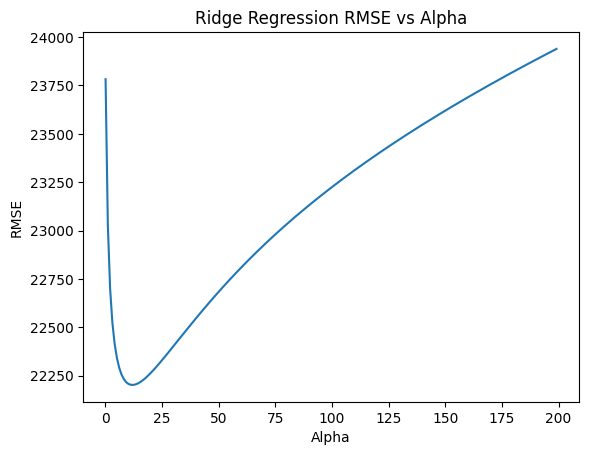

```
Best alpha:  12.1
Min error:  22202.77973498252
```

```python
import seaborn as sns
import matplotlib.pyplot as plt

# Extract the alpha values and rmse values from the dictionary
alphas = list(ridge_results.keys())

rmse_values = [value[0] for value in ridge_results.values()]
coefficients = [value[1] for value in ridge_results.values()]

# Plot the values
sns.lineplot(x=alphas, y=rmse_values)
plt.xlabel('Alpha')
plt.ylabel('RMSE')
plt.title('Ridge Regression RMSE vs Alpha')
plt.show()

min_alpha = min(ridge_results, key=lambda x: ridge_results[x])
print("Best alpha: ", min_alpha)
print("Min error: ", ridge_results[min_alpha][0])
```

Question 5.3: Using a visual, show how the model's coefficients changed as we gradually increased the shrinkage parameter `alpha`.

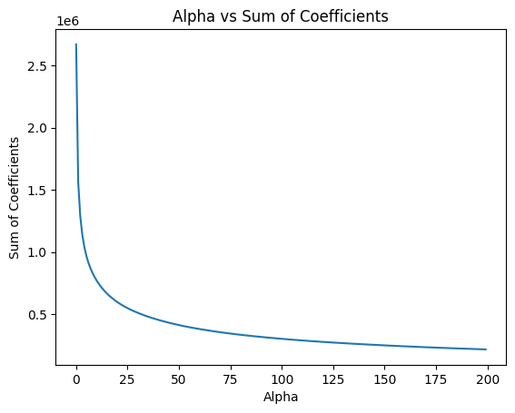

```python
alpha_values = list(ridge_results.keys())
coeff_sum = [sum(abs(coefficients)) for _, coefficients in ridge_results.values()]

# Plot alpha vs sum of coefficients
plt.plot(alpha_values, coeff_sum)
plt.xlabel('Alpha')
plt.ylabel('Sum of Coefficients')
plt.title('Alpha vs Sum of Coefficients')
plt.show()
```

Question 6: Repeat questions 5.1 - 5.3 using elasticnet experimenting with differnet values of alpha

```python
# from sklearn.model_selection import RandomizedSearchCV

# params = dict()

# # values for alpha: 100 values between e^-5 and e^5
# params['alpha'] =  np.logspace(-5, 5, 100, endpoint=True)

# model = ElasticNet(l1_ratio=0.1, alpha=0.006734150657750821)

# rs_cv= RandomizedSearchCV(model, params, n_iter = 500, scoring=None, cv=5, verbose=0, refit=True)
# rs_cv.fit(X_train, y_train.values.ravel())

# # Results
# Y_pred_elastic = rs_cv.predict(X_test)
# R2_score = rs_cv.score(X_test, y_test)
# RMSE_score = np.sqrt(mean_squared_error(y_test, Y_pred_elastic))

# print( "R2: ", R2_score, "RMSE: ", RMSE_score, "best params: ", rs_cv.best_params_ )

# This is shown in the Case Study
#pd.DataFrame({'linreg': lr.coef_, 'lasso': lasso.coef_}).head(10)

# Start with the same range as the ridge regression model
alpha_vals = np.arange(0.1, 200, 1)

# Create a dict to store the results of the RMSE
elastic_results = dict()

for alpha in alpha_vals:
    elastic = ElasticNet(alpha=alpha, max_iter=5_000)
    elastic.fit(X_train, y_train)
    y_pred_elastic = elastic.predict(X_test)
    rmse_elastic = np.sqrt(mean_squared_error(y_test, y_pred_elastic))
    elastic_results[alpha] = (rmse_elastic, elastic.coef_)
```

[output not shown]

[output cut: 188 more lines]

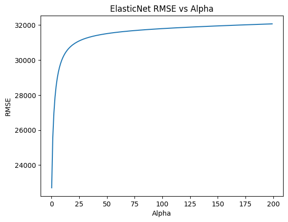

```
Best alpha:  0.1
Min error:  22696.27991440752
```

```python
alphas = list(elastic_results.keys())

rmse_values = [value[0] for value in elastic_results.values()]
coefficients = [value[1] for value in elastic_results.values()]

# Plot the values
sns.lineplot(x=alphas, y=rmse_values)
plt.xlabel('Alpha')
plt.ylabel('RMSE')
plt.title('ElasticNet RMSE vs Alpha')
plt.show()

min_alpha = min(elastic_results, key=lambda x: elastic_results[x])
print("Best alpha: ", min_alpha)
print("Min error: ", elastic_results[min_alpha][0])
```

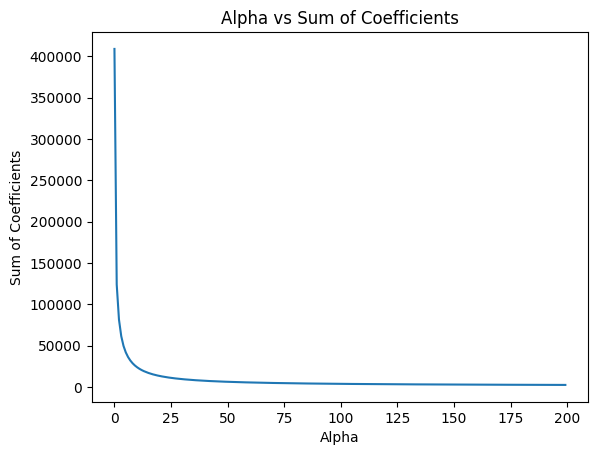

```python
coeff_sum = [sum(abs(coefficients)) for _, coefficients in elastic_results.values()]

# Plot alpha vs sum of coefficients
sns.lineplot(x=alphas, y=coeff_sum)
plt.xlabel('Alpha')
plt.ylabel('Sum of Coefficients')
plt.title('Alpha vs Sum of Coefficients')
plt.show()
```

Question 7: Based on the results, briefly describe the effect of changing `alpha` on the coefficients of both `Ridge`, `Lasso`, anf `ElasticNet`. What value of `alpha` would you choose for each case? You do not need to give a precise answer, but choose a number.

### Answer to 7

Based on the 3 models Ridge, Lasso and ElasticNet It seems that each algorithm had a different value of alpha that minimized the RMSE value of the predictions

In the table below is the Alpha that resulted in the lowest loss prediction and the RMSE is the amount of the minimum loss observed.

In all cases, it does seem like a rather large mean-squared error.

[output not shown]

Regarding the convergence of coefficients to zero as alpha increased: I wasn't sure how to graph 243 coefficients from the X data so I took the sum of the absolute values of the coefficients. For Ridge, Lasso and Elastic Net regression a trend toward zero of the sum of coefficients can be seen. (See graphs above)

What I find interesting is that even though coefficients are converging to zero as Alpha gets bigger, this does not necessarily represent the value of Alpha where the RMSE was minimized.

## Question 8:

Create a new text cell in your Notebook: Complete a 50-100 word summary (or short description of your thinking in applying this week's learning to the solution) of your experience in this assignment. Include:

What was your incoming experience with this model, if any? what steps you took, what obstacles you encountered. how you link this exercise to real-world, machine learning problem-solving. (What steps were missing? What else do you need to learn?) This summary allows your instructor to know how you are doing and allot points for your effort in thinking and planning, and making connections to real-world work

### Answer

After I got through with the second regression (Lasso with hyperparameter tuning of Alpha), this reminded me of some topics I was exposed to in a COursera course on Deep Learning. In that course they had a module called hyper-parameter tuning of Neural Networks. This week's exercise reminded me a lot of that prior exercise. DOing a little more research on the topic I discovered that Sci-kit Learn has some built in hyper-parameter tuning APIs. Namely, the GridSearchCV and RandomSearchCV are available for tuning parameters. In the final exercise with ElasticNet, I tried to utilize RandomSearch to tune the hyper parameter Alpha (this is commented out in my submission). I was a bit surprised that the resulting best Alpha found by RandomSearch wasn't exactly the same as what I found using the for loop method in my submission.

I am seeing that some very important steps in Machine Learning are:

1. Data cleansing, data normalizing
2. Model selection (choose the right model for the job)
3. Measure your model (reminds me of an Intel mantra: "If you don't measure it, you can't improve it.")
4. Tune your model parameters in order to improve it.

Admittedly, after reading the course textbook my understanding of Lasso and Ridge regression was not great. I had to seek out some other sources that explained the concepts with very simple examples. In particular [This video by Josh Starmer](https://www.youtube.com/watch?v=Xm2C_gTAl8c&t=272s) was great in explaining the concepts.